# Random Forests

# 1 Lectura de datos

```r
d = read.csv('datos/kidiq.csv')
d$mom_hs = factor(d$mom_hs, labels = c("no", "si"))
d$mom_work = factor(d$mom_work, labels = c("notrabaja", "trabaja23", "trabaja1_parcial", "trabaja1_completo"))
```

# 2 Training set *vs* Test set

Dividimos los datos en dos partes, una para entrenar el modelo y otra para calcular el error de predicción con datos diferentes de los utilizados para entrenar:

```r
set.seed(321)
n = nrow(d)
pos_train = sample(1:n,round(0.8*n)) # la mitad de los datos para entranamiento
datos_train = d[pos_train,] # trainning set
datos_test = d[-pos_train,] # test set
```

# 3 Random Forest

- Se remuestrea con reemplazamiento *B* veces (bootstrap).
- Se estima un arbol para cada muestra, $f_b(x)$. Pero cada vez que se divide un nodo en cada arbol, se seleccionan aleatoriamente *m* regresores de los *p* disponibles. Por defecto, R considera $p/3$. En el caso de que m = p se denomina **BAGGING**.
- Se calcula la predicción proporcionada por cada árbol, $\hat f_b(x)$.
- Se promedian las predicciones.

$$\hat f_{RF} = \frac{1}{B}\sum_{b=1}^B \hat f_b(x)$$

- La gran ventaja de random forest frente a bagging es que funciona muy bien con datos que tienen variables correlacionadas.

## 3.1 mtry = 4 (**BAGGING**)

```r
library(randomForest)
# numero total de regresores: 4
rf1 = randomForest(kid_score ~ ., data = datos_train, mtry = 4, ntree = 500)
```

Error del modelo:

```r
yp_train_rf1 <- predict(rf1, newdata = datos_train)
y_train = datos_train$kid_score
# error cuadratico medio en los datos de training
( MSE_train_rf1 = mean((y_train - yp_train_rf1)^2) )
```

```
## [1] 87.36114
```

Error de predicción:

```r
# prediccion del consumo con los datos test
yp_test_rf1 = predict(rf1, newdata = datos_test)

# error del test set
y_test = datos_test$kid_score
(MSE_test_rf1 = mean((y_test - yp_test_rf1)^2))
```

```
## [1] 380.8566
```

## 3.2 mtry = 3

```r
rf2 = randomForest(kid_score ~ ., data = datos_train, mtry = 3, ntree = 500)
```

Error del modelo:

```r
yp_train_rf2 <- predict(rf2, newdata = datos_train)
# error cuadratico medio en los datos de training
( MSE_train_rf2 = mean((y_train - yp_train_rf2)^2) )
```

```
## [1] 92.32
```

Error de predicción:

```r
# prediccion del consumo con los datos test
yp_test_rf2 = predict(rf2, newdata = datos_test)
# error del test set
(MSE_test_rf2 = mean((y_test - yp_test_rf2)^2))
```

```
## [1] 380.8993
```

## 3.3 mtry = 2

```r
rf3 = randomForest(kid_score ~ ., data = datos_train, mtry = 2, ntree = 500)
```

Error del modelo:

```r
yp_train_rf3 <- predict(rf3, newdata = datos_train)
# error cuadratico medio en los datos de training
( MSE_train_rf3 = mean((y_train - yp_train_rf3)^2) )
```

```
## [1] 116.7505
```

Error de predicción:

```r
# prediccion del consumo con los datos test
yp_test_rf3 = predict(rf3, newdata = datos_test)

# error del test set
(MSE_test_rf3 = mean((y_test - yp_test_rf3)^2))
```

```
## [1] 376.1012
```

# 4 Prediccion de un valor concreto

```r
# el paquete randomForest requiere que definamos las varibles cualitativas como factores
xp = data.frame(mom_iq = 95, mom_age = 30,
                mom_hs = factor("si", levels = c("no","si")),
                mom_work = factor("notrabaja", levels = c("notrabaja", "trabaja23", "trabaja1_parcial", "trabaja1_completo")) )
# la prediccion se calcula como el promedio de las predicciones de cada uno de los 500 arboles
predict(rf1, newdata = xp)
```

```
##        1
## 75.74037
```

# 5 Importancia de variables

```r
rf4 = randomForest(kid_score ~ ., data = datos_train, mtry = 4, ntree = 500, importance = T)
```

```r
importance(rf4)
```

```
##            %IncMSE IncNodePurity
## mom_hs    4.662314       3630.08
## mom_iq   44.337078      82797.27
## mom_work 11.665066      13623.48
## mom_age   6.490812      26319.00
```

- %IncMSE: incremento del MSE de las predicciones calculadas en los datos *out of samples* cuando los valores de una variable dada se permutan aleatoriamente (sería como quitarla del modelo). Cuando más grande es IncMSE, más importante es la variable.
- IncNodePurity: suma del descenso acumulado del RSS al partir por dicha variable.

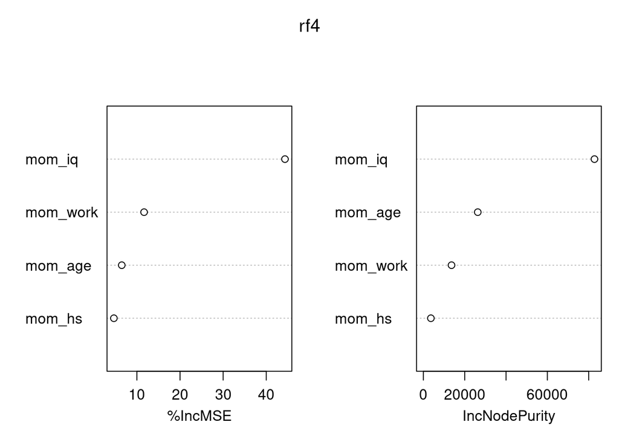

```r
varImpPlot(rf4)
```